# SC22: Quiz 01

October 13, 2022.

# Problem 0 [10 pts]

Successfully knit and submit both .rmd and .html

We give you the following `heart_disease` data; every problems in this quiz uses this dataset.

```r
library(tidyverse)
heart_disease_columns <- c(
  "age",      # age in years
  "sex",      # sex
              # - 1 = male
              # - 0 = female
  "cp",       # chest pain type
              # - 1 = typical angina
              # - 2 = atypical angina
              # - 3 = non-anginal pain
              # - 4 = asymptomatic
  "trestbps", # resting blood pressure (in mm Hg on admission to the hospital)
  "chol",     # serum cholestoral in mg/dl
  "fbs",      # fasting blood sugar > 120 mg/dl
              # - 1 = true
              # - 0 = false
  "restecg",  # resting electrocardiographic results
              # - 1 = normal
              # - 2 = having ST-T wave abnormality
              # - 3 = showing probable or definite left ventricular hypertrophy
  "thalach",  # maximum heart rate achieved
  "exang",    # exercise induced angina
              # - 1 = yes
              # - 0 = no
  "oldpeak",  # ST depression induced by exercise relative to rest
  "slope",    # the slope of the peak exercise ST segment
              # - 1 = upsloping
              # - 2 = flat
              # - 3 = downsloping
  "ca",       # number of major vessels (0-3) colored by flourosopy
  "thal",     # thal
              # - 3 = normal
              # - 6 = fixed defect
              # - 7 = reversable defect
  "num"       # diagnosis of heart disease (angiographic disease status)
              # - 0 = (< 50% diameter narrowing)
              # - 1 = (> 50% diameter narrowing)
              # - 2 = ?
              # - 3 = ?
              # - 4 = ?
)
heart_disease <- read_csv("processed.cleveland.data", col_types = cols(),
  col_names = heart_disease_columns, na = c("?")) %>%
  mutate(
    sex = factor(sex),
    cp = factor(cp),
    fbs = fbs > 0.5,
    restecg = factor(restecg),
    exang = exang > 0.5,
    slope = factor(slope),
    ca = as.integer(ca),
    thal = factor(thal),
    num = factor(num)
  )
```

```
## # A tibble: 303 x 14
##      age sex   cp    trestbps  chol fbs   restecg thalach exang oldpeak slope
##    <dbl> <fct> <fct>    <dbl> <dbl> <lgl> <fct>     <dbl> <lgl>   <dbl> <fct>
##  1    63 1     1          145   233 TRUE  2           150 FALSE     2.3 3
##  2    67 1     4          160   286 FALSE 2           108 TRUE      1.5 2
##  3    67 1     4          120   229 FALSE 2           129 TRUE      2.6 2
##  4    37 1     3          130   250 FALSE 0           187 FALSE     3.5 3
##  5    41 0     2          130   204 FALSE 2           172 FALSE     1.4 1
##  6    56 1     2          120   236 FALSE 0           178 FALSE     0.8 1
##  7    62 0     4          140   268 FALSE 2           160 FALSE     3.6 3
##  8    57 0     4          120   354 FALSE 0           163 TRUE      0.6 1
##  9    63 1     4          130   254 FALSE 2           147 FALSE     1.4 2
## 10    53 1     4          140   203 TRUE  2           155 TRUE      3.1 3
## # ... with 293 more rows, and 3 more variables: ca <int>, thal <fct>, num <fct>
```

# Problem 1 [20 pts]

Reproduce the following plot. **Your plot must be *exactly* same as the given plot, or you cannot get any points.**

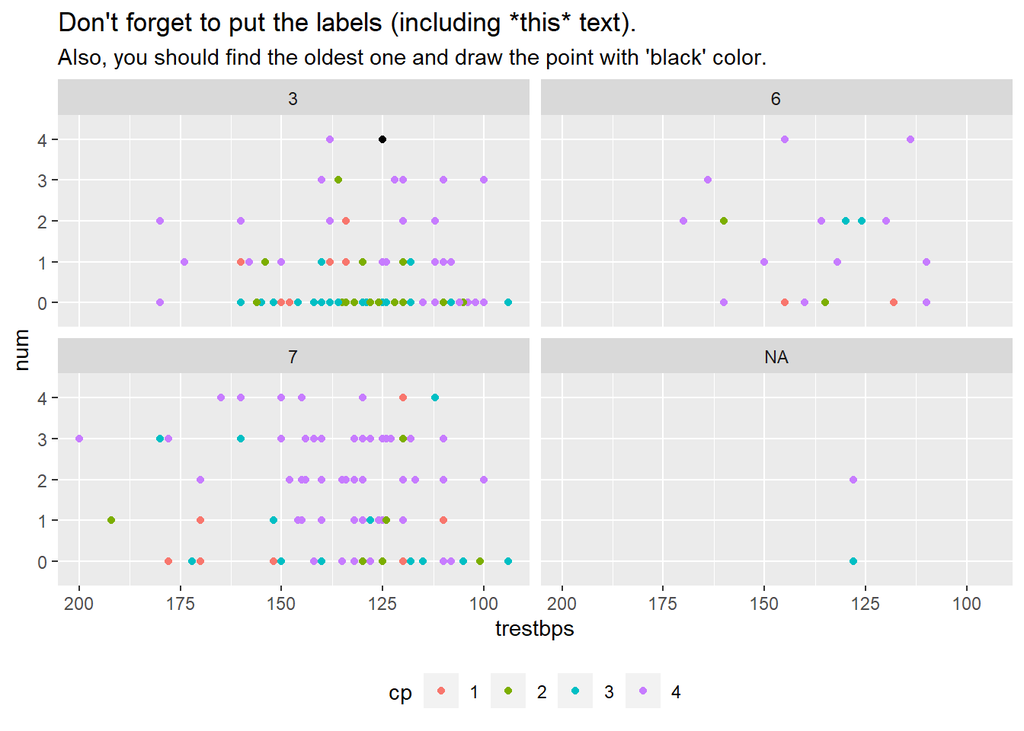

# Problem 2 [20 pts]

For each `sex`, compute the followings by using the patients diagnosed with heart disease (who’s `num` is `1`, `2`, `3`, or `4`).

1. Show the mean of the age as `mean_age`.
2. Show the most common cp type as `most_common_cp_type`.
3. Show the number of patients that are considered as `count`.

**Your result must have the same format below.** (All the column names, column type and object type must be identical to the given format.)

```
## # A tibble: 2 x 4
##   sex   mean_age most_common_cp_type count
##   <fct>    <dbl>               <int> <int>
## 1 0           NA                  NA    NA
## 2 1           NA                  NA    NA
```

# Problem 3 (Simpson’s paradox) [20 pts]

1. Reproduce the following figure using `stat_smooth` with `method="lm"`. What do you say about correlation between `age` and `chol`?

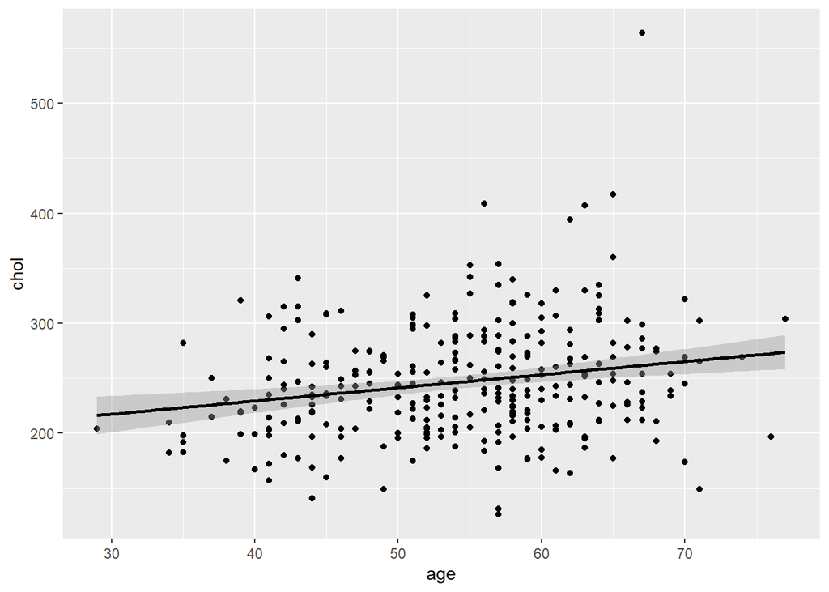

2. Reproduce the following figure. What do you say about correlation between `age` and `chol` when `num` is taken into consideration?

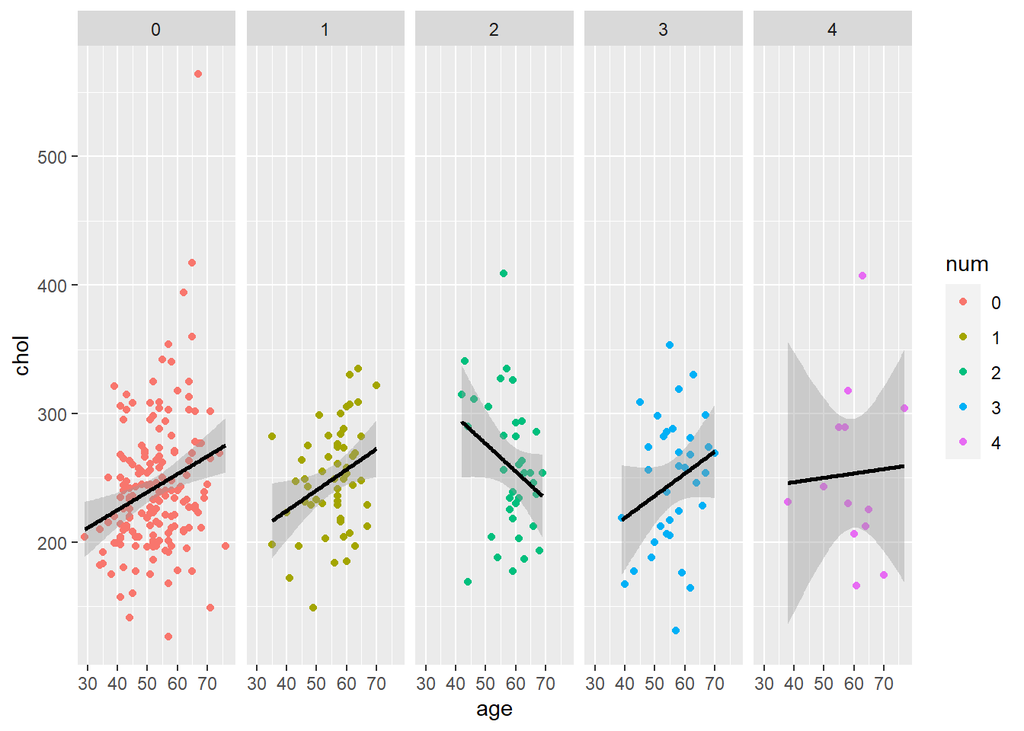